# profilepoint analysis Calcareous sedimentary rock

fabian gruber

October 24, 2017

How do those points that were classified correctly by the geologic map differ from those identified by the surveyors?

0 1 6 3 [1] “OBB error with all predictors of allpreds is 0.555555555555556” [1] “OBB error with all predictors of roughness is 0.222222222222222” [1] “OBB error with all predictors of localterrain is 0.444444444444444”

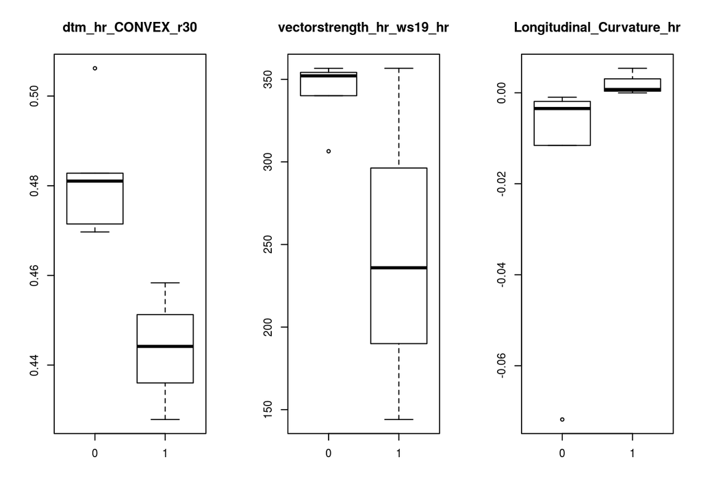

How about colluvial deposits

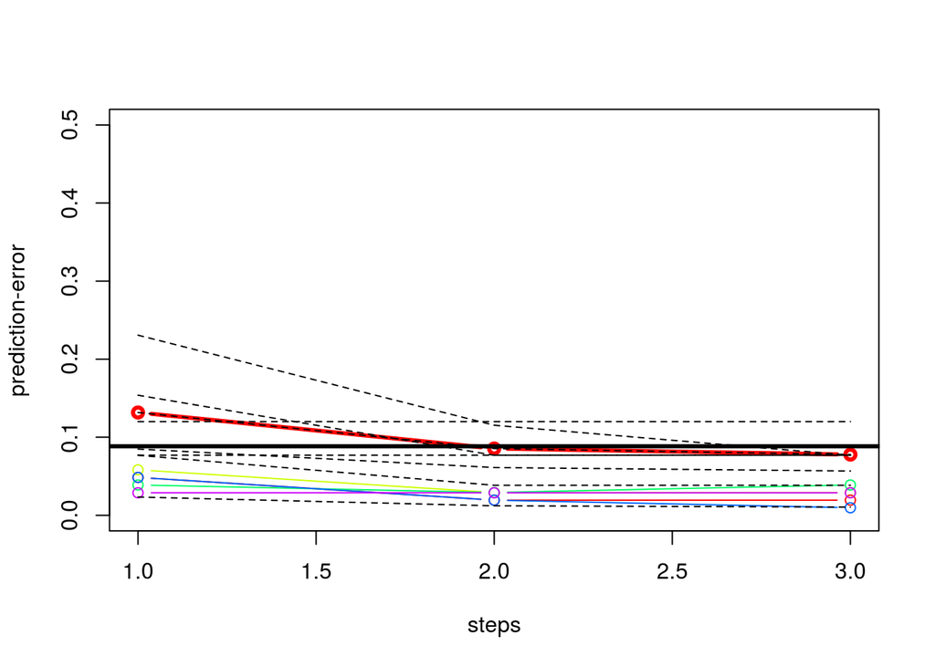

[1] “Prediction error at end is: 0.131692307692308” [2] “Prediction error at end is: 0.0855384615384615” [3] “Prediction error at end is: 0.0778461538461538”

| k 1 | k 2 | k 3 | k 4 | k 5 |
| --- | --- | --- | --- | --- |
| Convexity_10m | Convexity_10m | Convergence_Index_hr | slope_ws15_10m | TRI_hr_ws11 |
| dtm_hr_CONVEX_r30 | Vertical_Distance_to_Channel_Network_50m | dtm_hr_TEXTURE_r30 | profc_DTM_50m_avg_ws5_50m | TRI_hr_ws12 |
| Flow_Line_Curvature_50m | LSFactor_10m | planc_ws3_10m | vectorruggedness_hr_ws15 | slope_ws15_hr_hr |

[1] “OBB error with all predictors of allpreds is 0.062015503875969”

|  | CD | SD | MeanDecreaseAccuracy | MeanDecreaseGini |
| --- | --- | --- | --- | --- |
| SlopeHeight_10m | 0.0102333 | 0.0011728 | 0.0017918 | 0.1684970 |
| geom_hr_L50m_fl1_rplippatchnum_UE_hr_40cells_hr | 0.0021000 | 0.0012248 | 0.0012926 | 0.1917430 |
| profc_DTM_50m_avg_ws5_50m | 0.0058667 | 0.0007237 | 0.0011420 | 0.2305713 |
| geom_hr_L50m_fl1_rplippatchdensity_UE_hr_60cells_hr | 0.0001667 | 0.0011404 | 0.0011375 | 0.1348202 |
| Convexity_10m | 0.0089667 | 0.0004720 | 0.0010621 | 0.3397865 |
| longc_DTM_50m_avg_ws5_50m | 0.0095000 | 0.0005502 | 0.0010266 | 0.1318891 |
| geom_hr_L50m_fl1_rplipmps_UE_hr_60cells_hr | 0.0004667 | 0.0010765 | 0.0010035 | 0.1431267 |
| geom_hr_L50m_fl1_rplippatchnum_UE_hr_60cells_hr | 0.0026667 | 0.0007610 | 0.0009110 | 0.1062811 |
| geom_hr_L3_fl1_rplipdominance_UE_hr_10cells_hr | 0.0073000 | 0.0005174 | 0.0009098 | 0.1548589 |
| slope_ws11_hr_hr | 0.0035000 | 0.0007992 | 0.0008914 | 0.1018621 |

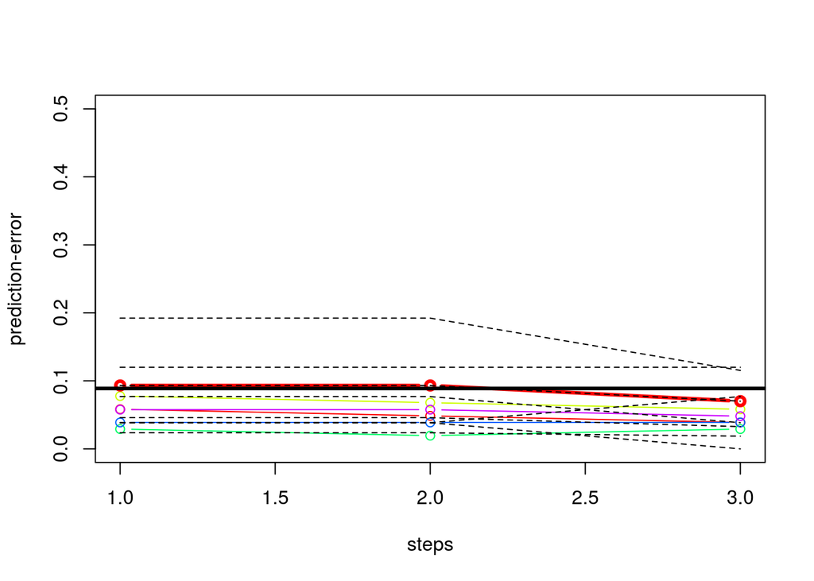

[1] “Prediction error at end is: 0.0932307692307692” [2] “Prediction error at end is: 0.0932307692307692” [3] “Prediction error at end is: 0.0701538461538461”

| k 1 | k 2 | k 3 | k 4 | k 5 |
| --- | --- | --- | --- | --- |
| vectorruggedness_hr_ws45 | geom_hr_L50m_fl1_rplipedgedensity_UE_hr_5cells_hr | geom_hr_L3_fl1_rplipsimpson_UE_hr_10cells_hr | TRI_hr_ws12 | geom_hr_L3_fl10_rplipdominance_UE_hr_5cells_hr |
| TRI_hr_ws24 | geom_hr_L50m_fl10_rplipedgedensity_UE_hr_20cells_hr | terraintexture_hr_ws57_tp25 | TRI_hr_ws13 | geom_hr_L3_fl10_rplipedgedensity_UE_hr_5cells_hr |
| geom_hr_L50m_fl10_rplippatchdensity_UE_hr_40cells_hr | TRI_hr_ws25 | vectorstrength_hr_ws3_hr | TRI_hr_ws11 | TRI_hr_ws29 |

[1] “OBB error with all predictors of roughness is 0.0697674418604651”

|  | CD | SD | MeanDecreaseAccuracy | MeanDecreaseGini |
| --- | --- | --- | --- | --- |
| geom_hr_L3_fl1_rplipmps_UE_hr_40cells_hr | 0.0135333 | 0.0010225 | 0.0018375 | 0.2895065 |
| geom_hr_L3_fl1_rplippatchdensity_UE_hr_60cells_hr | 0.0068000 | 0.0011636 | 0.0016416 | 0.2583070 |
| geom_hr_L50m_fl1_rplippatchdensity_UE_hr_60cells_hr | 0.0028000 | 0.0014162 | 0.0015005 | 0.1583740 |
| TRI_hr_ws37 | 0.0006333 | 0.0014342 | 0.0014247 | 0.0744943 |
| TRI_hr_ws43 | -0.0006667 | 0.0014932 | 0.0013754 | 0.1177978 |
| geom_hr_L3_fl1_rplipdominance_UE_hr_10cells_hr | 0.0090000 | 0.0007404 | 0.0013121 | 0.2412176 |
| geom_hr_L3_fl1_rplippatchnum_UE_hr_40cells_hr | 0.0072000 | 0.0008292 | 0.0012889 | 0.2065646 |
| TRI_hr_ws13 | 0.0059000 | 0.0009367 | 0.0012885 | 0.1946512 |
| TRI_hr_ws14 | 0.0030000 | 0.0010389 | 0.0012040 | 0.0934811 |
| TRI_hr_ws4 | 0.0027667 | 0.0008807 | 0.0010851 | 0.1190044 |

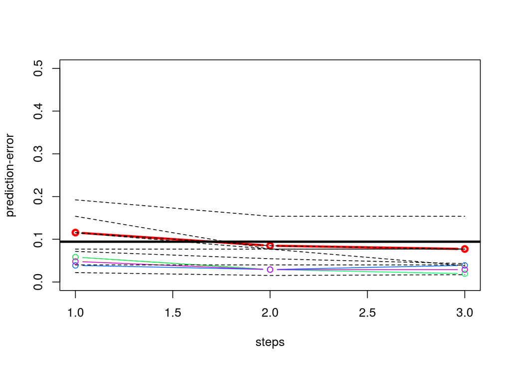

[1] “Prediction error at end is: 0.115692307692308” [2] “Prediction error at end is: 0.0849230769230769” [3] “Prediction error at end is: 0.0772307692307692”

| k 1 | k 2 | k 3 | k 4 | k 5 |
| --- | --- | --- | --- | --- |
| profc_ws11_10m | crosc_ws11_hr_hr | Convexity_10m | longc_ws3_10m | Convexity_10m |
| longc_ws11_10m | maxic_ws11_hr_hr | crosc_ws23_hr_hr | crosc_ws5_hr_hr | minic_ws9_hr_hr |
| slope_ws15_10m | crosc_ws23_hr_hr | minic_ws7_hr_hr | profc_DTM_50m_avg_ws5_50m | profc_DTM_50m_avg_ws7_50m |

[1] “OBB error with all predictors of localterrain is 0.062015503875969”

|  | CD | SD | MeanDecreaseAccuracy | MeanDecreaseGini |
| --- | --- | --- | --- | --- |
| Convexity_10m | 0.0302000 | 0.0021853 | 0.0041165 | 0.8858025 |
| slope_DTM_50m_avg_ws5_50m | 0.0106333 | 0.0034664 | 0.0039413 | 0.2668244 |
| profc_DTM_50m_avg_ws5_50m | 0.0192714 | 0.0027021 | 0.0036704 | 0.4987994 |
| slope_DTM_50m_avg_ws11_50m | 0.0156333 | 0.0027162 | 0.0035687 | 0.4653851 |
| slope_ws11_hr_hr | 0.0168333 | 0.0023590 | 0.0032888 | 0.4001203 |
| slope_DTM_50m_avg_ws9_50m | 0.0037024 | 0.0029631 | 0.0031747 | 0.4858334 |
| slope_ws15_10m | 0.0129048 | 0.0022519 | 0.0030649 | 0.4130831 |
| Slope_50m | 0.0168000 | 0.0020476 | 0.0030261 | 0.4206253 |
| slope_ws23_hr_hr | 0.0092333 | 0.0021203 | 0.0025997 | 0.2930270 |
| slope_DTM_50m_avg_ws7_50m | -0.0008095 | 0.0025632 | 0.0025390 | 0.2999245 |

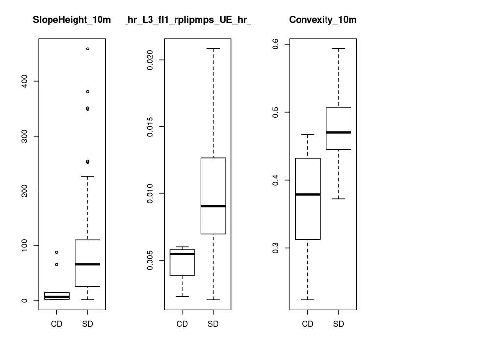

How does this compare to the differences between the units on the geological map?

[1] “OBB error with all predictors of allpreds is 0.0489655172413793”

|  | CD | SD | MeanDecreaseAccuracy | MeanDecreaseGini |
| --- | --- | --- | --- | --- |
| slope_DTM_50m_avg_ws9_50m | 0.0319061 | 0.0092671 | 0.0137645 | 10.110334 |
| TRI_hr_ws44 | 0.0156726 | 0.0094290 | 0.0106668 | 7.662950 |
| TRI_hr_ws50 | 0.0071722 | 0.0107417 | 0.0100493 | 6.828323 |
| slope_DTM_50m_avg_ws7_50m | 0.0211535 | 0.0070755 | 0.0098380 | 4.333093 |
| slope_DTM_50m_avg_ws11_50m | 0.0283984 | 0.0051958 | 0.0097743 | 6.931941 |
| TRI_hr_ws45 | 0.0113471 | 0.0086348 | 0.0092085 | 7.633340 |
| TRI_hr_ws49 | 0.0069786 | 0.0091155 | 0.0086949 | 4.943051 |
| TRI_hr_ws47 | 0.0120979 | 0.0072108 | 0.0082126 | 6.641295 |
| slope_DTM_50m_avg_ws5_50m | 0.0191950 | 0.0055154 | 0.0082051 | 7.336440 |
| TRI_hr_ws43 | 0.0149577 | 0.0064616 | 0.0081044 | 9.041145 |

[1] “OBB error with all predictors of roughness is 0.0730027548209366”

|  | CD | SD | MeanDecreaseAccuracy | MeanDecreaseGini |
| --- | --- | --- | --- | --- |
| TRI_hr_ws49 | 0.0157583 | 0.0168706 | 0.0166882 | 10.757571 |
| TRI_hr_ws47 | 0.0183061 | 0.0140047 | 0.0148244 | 11.720586 |
| TRI_hr_ws48 | 0.0118270 | 0.0153899 | 0.0146734 | 7.530273 |
| TRI_hr_ws43 | 0.0138149 | 0.0144020 | 0.0143332 | 10.088935 |
| TRI_hr_ws50 | 0.0132635 | 0.0144932 | 0.0142648 | 6.836835 |
| TRI_hr_ws45 | 0.0139942 | 0.0138289 | 0.0138413 | 11.837439 |
| TRI_hr_ws44 | 0.0127717 | 0.0134611 | 0.0133660 | 11.971617 |
| TRI_hr_ws46 | 0.0114331 | 0.0138705 | 0.0133435 | 8.321681 |
| TRI_hr_ws39 | 0.0181028 | 0.0112379 | 0.0125835 | 13.186234 |
| TRI_hr_ws41 | 0.0162019 | 0.0104059 | 0.0115781 | 10.140787 |

[1] “OBB error with all predictors of localterrain is 0.0715760495526497”

|  | CD | SD | MeanDecreaseAccuracy | MeanDecreaseGini |
| --- | --- | --- | --- | --- |
| slope_DTM_50m_avg_ws11_50m | 0.0901436 | 0.0156898 | 0.0306942 | 32.24860 |
| slope_DTM_50m_avg_ws9_50m | 0.0791796 | 0.0130328 | 0.0262197 | 26.77902 |
| slope_DTM_50m_avg_ws7_50m | 0.0509320 | 0.0116839 | 0.0195240 | 23.62735 |
| slope_ws15_10m | 0.0285239 | 0.0157801 | 0.0182485 | 17.64534 |
| slope_ws11_10m | 0.0337621 | 0.0122813 | 0.0165174 | 22.43969 |
| slope_DTM_50m_avg_ws3_50m | 0.0241934 | 0.0142909 | 0.0162589 | 20.29001 |
| slope_DTM_50m_avg_ws5_50m | 0.0294068 | 0.0112684 | 0.0149154 | 13.97365 |
| Slope_50m | 0.0264114 | 0.0083915 | 0.0119309 | 16.61208 |
| slope_ws15_hr_hr | 0.0185529 | 0.0076749 | 0.0099014 | 12.19020 |
| slope_ws29_hr_hr | 0.0188773 | 0.0072284 | 0.0095890 | 11.69972 |

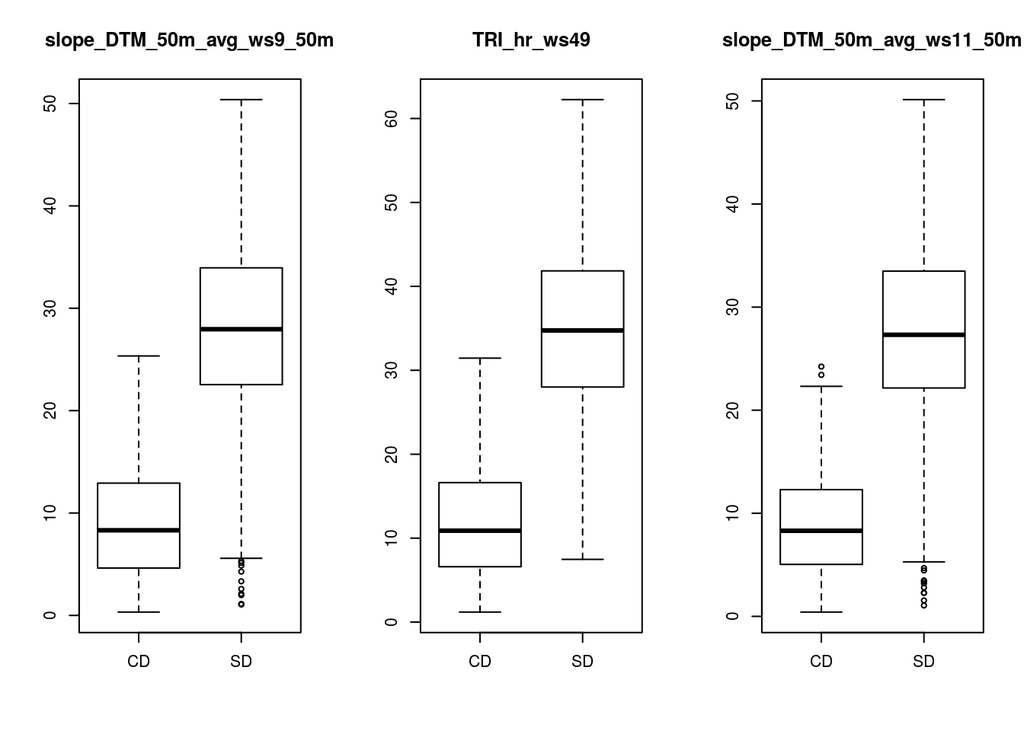